# Survival rate on the Titanic

Yuyu Zeng

December 22, 2016

# Load packages

```r
library("caret")
library("randomForest")
```

```r
library("rpart")
library("tree")
#library("rattle")
library("rpart.plot")
set.seed(2)
train <- read.csv('train.csv')
test  <- read.csv('test.csv')
```

# Create the training and testing data set

```r
inTrain <- createDataPartition(train$Survived, p=.75, list = FALSE)
training <- train[inTrain,]
testing <- training[-inTrain,]
```

Firstly, we read the train and test datasets. Then we further split the train dataset into training and testing datasets for our machine learning models.

# Feature engineering

## Dealing with missing values and transformations in the training dataset

```r
#head(training)
# Grab title from passenger names
training$Title <- gsub('(.*, )|(\\..*)', '', training$Name)
testing$Title <- gsub('(.*, )|(\\..*)', '', testing$Name)
#head(training)
#head(testing)
#nrow(training)
#unique(training$Title)
#unique(testing$Title)
#unique(testing$Title) %in% unique(training$Title)
#imputing missing values for "Age" in the training and testing dataset based on the information in the training dataset
for (i in 1:length(unique(training$Title))){
  title <- unique(training$Title)[i]
  #print(title)
  mean_title <- mean(training[training$Title == title,'Age'],na.rm=TRUE)
  #print(mean_title)
  number_training <- 0
  number_testing <- 0
  for (j in 1:nrow(training)){
  if (is.na(training$Age[j]) & training$Title[j] ==title){
      number_training <- number_training+1
      training$Age[j] <- mean_title
  }
  }
  #print(number_training)
  for (k in 1:nrow(testing)){
  if (is.na(testing$Age[k]) & testing$Title[k] ==title){
      number_testing <- number_testing +1
      testing$Age[k] <- mean_title
  }
  }
  #print(number_testing)
}

myfeature <- c("Pclass", "Sex", "Age", "SibSp", "Parch", "Fare", "Cabin", "Embarked","Survived")
newtraining <- training[, which(names(training) %in% myfeature)]
#convert Pclass from interger to factor level
newtraining$Pclass <- as.factor(newtraining$Pclass)
newtraining$Sex <- as.factor(newtraining$Sex)
#summary(newtraining)
#str(newtraining)

#Check missing values
sum(newtraining$Cabin == '')/nrow(newtraining)
```

```
## [1] 0.7847534
```

```r
newtraining <- within(newtraining, rm(Cabin))
#head(newtraining)
sapply(newtraining, function(x) sum(is.na(x)))
```

```
## Survived   Pclass      Sex      Age    SibSp    Parch     Fare Embarked
##        0        0        0        0        0        0        0        0
```

```r
dim(newtraining)
```

```
## [1] 669   8
```

```r
newtraining[newtraining==""] <- NA
newtraining <- na.omit(newtraining)
dim(newtraining)
```

```
## [1] 667   8
```

```r
#str(newtraining)
#head(newtraining)
```

Intuitively we think ticket number and passenger ID are mostly probably irrelevant for their survival rate. We use “myfeature” to collect relevant features. Among all relevant features, “Pclass”" has three levels 1, 2 and 3. For “Sex”" we have both male and female. Both “Pclass” and “Sex” are stored in factor variables. We also notice that a lot of missing values for “Age” and it accounts for roughly 20 percent. Hence, we face the problem of how to impute the missing values for the “Age” variable. We extract passenger title from their names and impute the missing information of age by inserting the mean age of the corresponding group classified by title. “SibSp”, “Parch” and “Fare”" are stored in numerical values. “Embarked” are stored in factor variables. More than 75 percent of “Cabin” information is empty. Therefore, we decide to discard the information of “Cabin”.

## Transformation in the testing test

We do similar transformations in the testing data sets, i.e., grabbing relevant features, converting passenger class into factor variables, removing the feature of “Cabin”. At the end, we can see there is no missing values in our features matrix anymore.

```r
newtesting <- testing[, which(names(testing) %in% myfeature)]
# convert Pclass from interger to factor level
newtesting$Pclass <- as.factor(newtesting$Pclass)
newtesting$Sex <- as.factor(newtesting$Sex)
# remove cabin information
newtesting <- within(newtesting, rm(Cabin))
# remove rows with missing values
dim(newtesting)
```

```
## [1] 175   8
```

```r
newtesting[newtesting==""] <- NA
newtesting <- na.omit(newtesting)
sapply(newtesting, function(x) sum(is.na(x)))
```

```
## Survived   Pclass      Sex      Age    SibSp    Parch     Fare Embarked
##        0        0        0        0        0        0        0        0
```

```r
dim(newtesting)
```

```
## [1] 175   8
```

# Machine Learning Models

## logistic regression

```r
model_log <- glm(as.factor(Survived) ~.,family=binomial(link='logit'),data=newtraining)
summary(model_log)
```

```
##
## Call:
## glm(formula = as.factor(Survived) ~ ., family = binomial(link = "logit"),
##     data = newtraining)
##
## Deviance Residuals:
##     Min       1Q   Median       3Q      Max
## -2.3294  -0.5812  -0.3753   0.5982   2.5606
##
## Coefficients:
##              Estimate Std. Error z value Pr(>|z|)
## (Intercept)  4.692205   0.569749   8.236  < 2e-16 ***
## Pclass2     -1.118144   0.351556  -3.181  0.00147 **
## Pclass3     -2.365632   0.351542  -6.729 1.70e-11 ***
## Sexmale     -2.831283   0.237843 -11.904  < 2e-16 ***
## Age         -0.048946   0.009474  -5.166 2.39e-07 ***
## SibSp       -0.249561   0.119486  -2.089  0.03674 *
## Parch       -0.182607   0.138108  -1.322  0.18610
## Fare         0.002252   0.002705   0.833  0.40510
## EmbarkedQ   -0.302288   0.453011  -0.667  0.50459
## EmbarkedS   -0.550760   0.277379  -1.986  0.04708 *
## ---
## Signif. codes:  0 '***' 0.001 '**' 0.01 '*' 0.05 '.' 0.1 ' ' 1
##
## (Dispersion parameter for binomial family taken to be 1)
##
##     Null deviance: 889.25  on 666  degrees of freedom
## Residual deviance: 564.78  on 657  degrees of freedom
## AIC: 584.78
##
## Number of Fisher Scoring iterations: 5
```

```r
predict <- predict(model_log, type = 'response')
tab_training <- table(newtraining$Survived, predict>0.5)
sum(diag(tab_training))/sum(tab_training)
```

```
## [1] 0.808096
```

```r
predict_test <- predict(model_log, newtesting[2:8], type="response")
tab_testing <- table(newtesting$Survived, predict_test>0.5)
sum(diag(tab_testing))/sum(tab_testing)
```

```
## [1] 0.7885714
```

## random forest models

```r
model_rfm <- randomForest(as.factor(Survived) ~., data = newtraining)
predict <- predict(model_rfm, type = 'response')
tab_training <- table(newtraining$Survived, predict)
sum(diag(tab_training))/sum(tab_training)
```

```
## [1] 0.8035982
```

```r
predict_test <- predict(model_rfm, newtesting[2:8], type="response")
tab_testing <- table(newtesting$Survived, predict_test)
sum(diag(tab_testing))/sum(tab_testing)
```

```
## [1] 0.92
```

## decision tree model

```r
str(newtraining)
```

```
## 'data.frame':    667 obs. of  8 variables:
##  $ Survived: int  0 1 0 0 0 0 1 1 1 0 ...
##  $ Pclass  : Factor w/ 3 levels "1","2","3": 3 1 3 3 1 3 3 2 3 3 ...
##  $ Sex     : Factor w/ 2 levels "female","male": 2 1 2 2 2 2 1 1 1 2 ...
##  $ Age     : num  22 38 35 32.3 54 ...
##  $ SibSp   : int  1 1 0 0 0 3 0 1 1 0 ...
##  $ Parch   : int  0 0 0 0 0 1 2 0 1 0 ...
##  $ Fare    : num  7.25 71.28 8.05 8.46 51.86 ...
##  $ Embarked: Factor w/ 4 levels "","C","Q","S": 4 2 4 3 4 4 4 2 4 4 ...
##  - attr(*, "na.action")=Class 'omit'  Named int [1:2] 46 621
##   .. ..- attr(*, "names")= chr [1:2] "62" "830"
```

```r
model_dtm <-rpart(Survived~.,newtraining, method = "class")
#summary(model_dtm)
predict <-predict(model_dtm,newtesting, type="class")
#predict
tab_training <- table(newtesting$Survived, predict)
tab_training
```

```
##    predict
##      0  1
##   0 94 14
##   1 12 55
```

```r
sum(diag(tab_training))/sum(tab_training)
```

```
## [1] 0.8514286
```

```r
predict_test <- predict(model_rfm, newtesting[2:8], type="class")
tab_testing <- table(newtesting$Survived, predict_test)
sum(diag(tab_testing))/sum(tab_testing)
```

```
## [1] 0.92
```

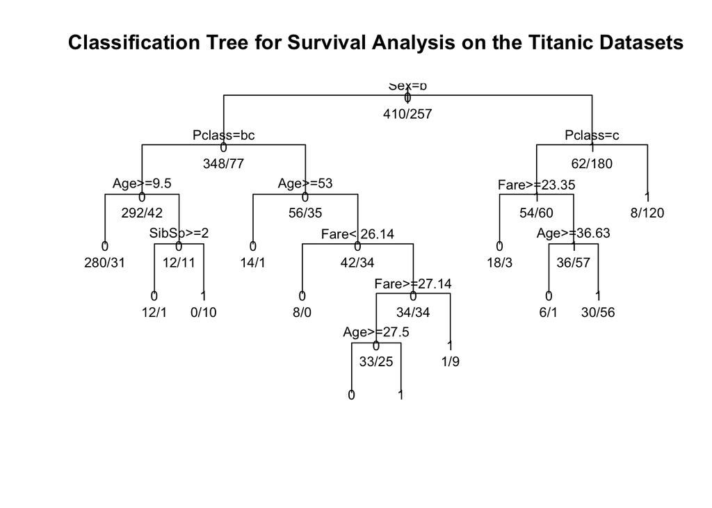

```r
plot(model_dtm, uniform=TRUE, main="Classification Tree for Survival Analysis on the Titanic Datasets")
text(model_dtm, use.n=TRUE, all=TRUE, cex=.8)
```